# Ejercicios Modelos

Maria Jose Corea

2022-10-15

2.16 Un estudio de bebés planteó la hipótesis de que los bebés tardarían más en aprender a gatear en los meses más fríos porque la ropa extra restringe su movimiento. Entre 1988 y 1991, la primera edad de gateo de los bebés y el promedio se registró la temperatura mensual seis meses después del nacimiento (cuando “los bebés presumiblemente entran en la ventana de preparación locomotora”; p. 72). Los padres informaron el mes de nacimiento y la edad en que su bebé se arrastró o gateó por primera vez distancia de cuatro pies en un minuto. Los datos fueron recolectados en la Universidad de Denver Infant Study Center sobre 208 niños y 206 niñas, y resumido por el mes de nacimiento (Tabla 2.10; conjunto de datos: rastreo). 1. Trazar los datos. ¿Qué suposiciones, si las hubiere, parecen violarse? 2. Explique por qué un modelo de regresión ponderado es apropiado para los datos. 3. Ajuste un modelo de regresión lineal ponderado a los datos e interprete el coeficientes de regresión. 4. Probar formalmente la hipótesis propuesta por los investigadores. 5. Encuentre un intervalo de confianza del 90 % para la pendiente de la línea ajustada, y interpretar. 6. Ajuste el modelo de regresión no ponderado, luego trace ambas líneas de regresión en una trama de los datos. Comenta las diferencias. 7. Calcule los intervalos de confianza del 95 % para los valores ajustados de la línea de regresión ponderada, y también grafíquelos. 8. Interpreta el modelo.

```r
Babies <- read.csv("~/GitHub/II-2022/Modelos Lineales/Base.txt")

colnames(Babies) <- c('Mes', 'PromedioSemanas','Frecuencia', 'PromedioTemperatura')
```

1.R

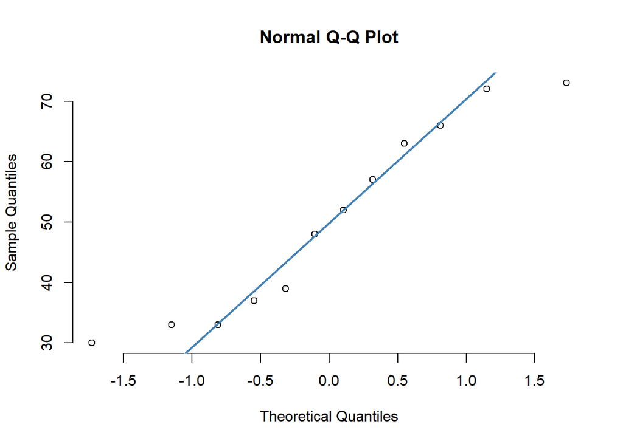

```r
qqnorm(Babies$PromedioTemperatura, pch = 1, frame = FALSE)
qqline(Babies$PromedioTemperatura, col = "steelblue", lwd = 2)
```

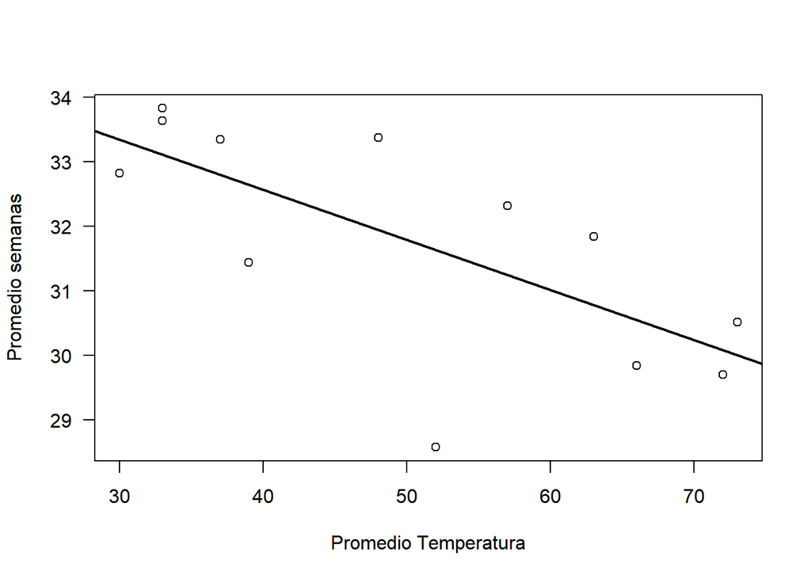

```r
p <- lm(PromedioSemanas ~ PromedioTemperatura, data=Babies)

plot( PromedioSemanas ~ PromedioTemperatura, data=Babies, las=1,
xlab="Promedio Temperatura", ylab="Promedio semanas" )
abline( coef(p), lty=1, lwd=2)
```

Al realizar la comparación del promedio de semanas hasta gatear y el rpomedio de la temperatura en los siguientes 6 meses, se puede observar una relativa linealidad decreciente, es decir, que en cuanto más frío esté, menos son los reportes de que los niños gateen. Y se encuentra un outlyer entre 50 y 60.

2.R

Porque la regresión ponderada se puede utilizar para corregir la heterocedasticidad. En un procedimiento de regresión ponderada, se otorga más peso a las observaciones con una varianza más pequeña porque estas observaciones brindan información más confiable sobre la función de regresión que aquellas con varianzas grandes. Observemos que la varianza de las observaciones, asimismo la desviación estándar y un histograma para ver si se ve normalidad.

```r
var(Babies$PromedioTemperatura)
```

```
## [1] 251.1136
```

```r
sd(Babies$PromedioTemperatura)
```

```
## [1] 15.84657
```

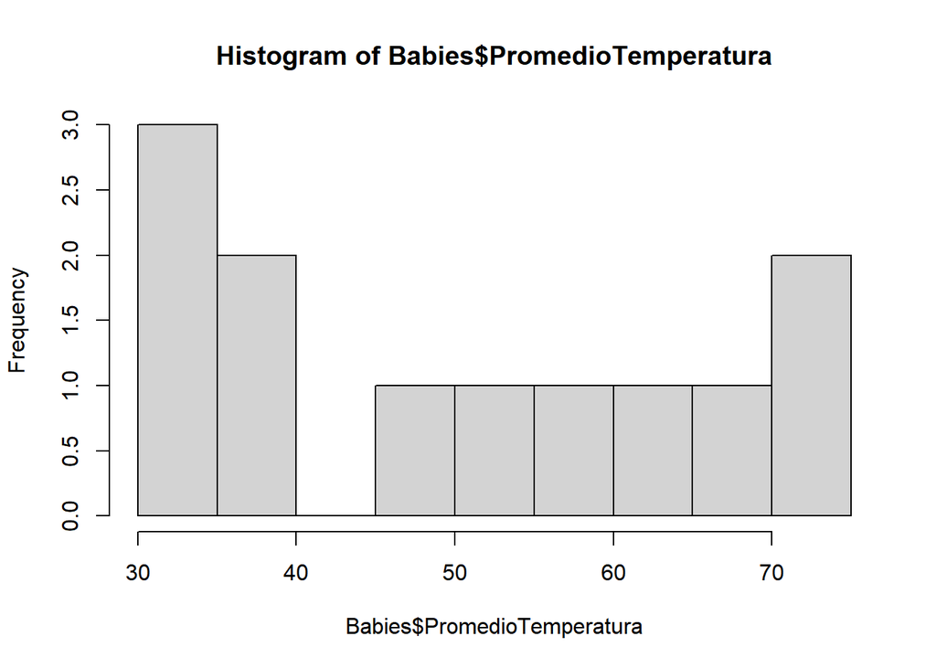

```r
hist(Babies$PromedioTemperatura, breaks = 12)
```

3.R/

```r
mod_ols <- lm(Babies$PromedioTemperatura~ Babies$PromedioSemanas + I(Babies$PromedioSemanas^2))  #Modelo de mínimos cuadrados ordinarios

mod_pond <-
  lm(
    I(sqrt(Babies$Frecuencia) * Babies$PromedioTemperatura) ~ 0 + sqrt(Babies$Frecuencia) + I(sqrt(Babies$Frecuencia) * Babies$PromedioSemanas) + I(sqrt(Babies$Frecuencia) *
                                                                                                                                                      Babies$PromedioSemanas ^ 2)
  )

mod_leo <-  lm(PromedioSemanas ~ PromedioTemperatura, data=Babies, weights = Frecuencia)

coef(mod_leo)
```

```
##         (Intercept) PromedioTemperatura
##         35.70253928         -0.07560731
```

```r
coef(mod_ols)
```

```
##                 (Intercept)      Babies$PromedioSemanas
##                -1994.425857                  137.156782
## I(Babies$PromedioSemanas^2)
##                   -2.284964
```

```r
coef(mod_pond)
```

```
##                               sqrt(Babies$Frecuencia)
##                                          -1851.877834
##   I(sqrt(Babies$Frecuencia) * Babies$PromedioSemanas)
##                                            127.996607
## I(sqrt(Babies$Frecuencia) * Babies$PromedioSemanas^2)
##                                             -2.138151
```

Se puede notar la diferencia en los coeficientes, o sea son modelos distintos

```r
summary(mod_pond)
```

```
##
## Call:
## lm(formula = I(sqrt(Babies$Frecuencia) * Babies$PromedioTemperatura) ~
##     0 + sqrt(Babies$Frecuencia) + I(sqrt(Babies$Frecuencia) *
##         Babies$PromedioSemanas) + I(sqrt(Babies$Frecuencia) *
##         Babies$PromedioSemanas^2))
##
## Residuals:
##     Min      1Q  Median      3Q     Max
## -106.79  -18.62   12.12   37.47   68.11
##
## Coefficients:
##                                                        Estimate Std. Error
## sqrt(Babies$Frecuencia)                               -1851.878   1410.096
## I(sqrt(Babies$Frecuencia) * Babies$PromedioSemanas)     127.997     89.900
## I(sqrt(Babies$Frecuencia) * Babies$PromedioSemanas^2)    -2.138      1.429
##                                                       t value Pr(>|t|)
## sqrt(Babies$Frecuencia)                                -1.313    0.222
## I(sqrt(Babies$Frecuencia) * Babies$PromedioSemanas)     1.424    0.188
## I(sqrt(Babies$Frecuencia) * Babies$PromedioSemanas^2)  -1.496    0.169
##
## Residual standard error: 64.43 on 9 degrees of freedom
## Multiple R-squared:  0.9658, Adjusted R-squared:  0.9544
## F-statistic: 84.66 on 3 and 9 DF,  p-value: 6.472e-07
```

El modelo es bastante significativo